# 6. Beyond two-host SIRS: custom SEIR and multi-deme bridge-reservoir phylodynamics

Phylodynamics.jl vignettes

Author

Simon D. W. Frost

Published

October 28, 2026

## Overview

Because `Phylodynamics.jl` compiles `ModelingToolkit.ReactionSystem`s into `ModelFGY` and `TFGY` objects via stoichiometric inspection (`classify_phylodynamic_reactions`), **any** compartmental epidemic model written in `ModelingToolkit.jl` or `Catalyst.jl` can immediately be used to simulate structured genealogies (`TreeProblem`) and compute structured coalescent likelihoods (`colik`, `ace`).

In this vignette we build two custom multi-deme models from scratch:

1. **An Exposed–Infectious (SEIR) model** (`infected = [E, I]`), where new infections enter latent stage `E` (`:transmission`) and progress into infectious stage `I` (`:migration`), illustrating stage-progression phylodynamics.
2. **A 3-deme wildlife–livestock–human bridge-reservoir chain** (`infected = [Y1, Y2, Y3]`), where a pathogen spills over from wildlife (`Y1`) into an amplifying livestock intermediate host (`Y2`) and subsequently into humans (`Y3`), with 3-state ancestral host reconstruction via `ace`.

## Example 1: Stage-structured SEIR phylodynamics (`infected = [E, I]`)

In an SEIR epidemic, transmission `S + I --> E + I` has parent `I` (deme 2) and newly created infected individual `E` (deme 1), so $F_{2,1} = \beta S I / N$. Latency progression `E --> I` has net infected stoichiometry $0$ ($-1$ in `E`, $+1$ in `I`), so it is automatically classified as `:migration` $G_{1,2} = \sigma E$:

```julia
using Phylodynamics
using ModelingToolkit
using Catalyst
using SciMLBase
using OrdinaryDiffEqTsit5
using CairoMakie
using DataFrames
using StableRNGs

t = ModelingToolkit.t_nounits
@parameters beta sigma gamma N
@species S(t) E(t) I(t) R(t)

seir_rxs = [
    Reaction(beta / N, [S, I], [E, I], [1, 1], [1, 1]), # I transmits, new infection starts in E
    Reaction(sigma, [E], [I], [1], [1]),                # latent progression E -> I (migration)
    Reaction(gamma, [I], [R], [1], [1])                 # recovery I -> R (removal)
]
@named seir_rs = ReactionSystem(seir_rxs, t, [S, E, I, R], [beta, sigma, gamma, N]; combinatoric_ratelaws = false)
seir_rs = complete(seir_rs)

seir_specs = classify_phylodynamic_reactions(seir_rs, [E, I])
DataFrame(
    rx = [s.rx_index for s in seir_specs],
    role = [s.role for s in seir_specs],
    from_deme = [s.parent_deme == 0 ? "-" : ["E", "I"][s.parent_deme] for s in seir_specs],
    to_deme = [s.child_deme == 0 ? "-" : ["E", "I"][s.child_deme] for s in seir_specs]
)
```

3×4 DataFrame

| Row | rx Int64 | role Symbol | from_deme String | to_deme String |
| --- | --- | --- | --- | --- |
| 1 | 1 | transmission | I | E |
| 2 | 2 | migration | E | I |
| 3 | 3 | removal | I | - |

Let us simulate an SEIR genealogy sampled at $T = 30$ days ($10$ latent `E` tips and $30$ infectious `I` tips) and evaluate its structured coalescent log-likelihood across candidate transmission rates $\beta$:

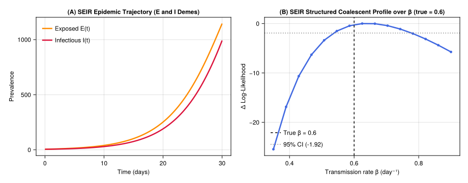

```julia
u0_seir = [S => 9990.0, E => 5.0, I => 5.0, R => 0.0]
p_seir  = [beta => 0.6, sigma => 0.25, gamma => 0.15, N => 10000.0]
tspan_seir = (0.0, 30.0)

prob_seir = TreeProblem(seir_rs, [E, I], u0_seir, tspan_seir, p_seir, [E => 10, I => 30])
tree_seir = solve(prob_seir, CoalescentStepper(); rng = StableRNG(2026))

dm_seir = build_demographic_process(seir_rs, [E, I], u0_seir, tspan_seir, p_seir)
bdt_seir = DatedTree(tree_seir; demes = ["E", "I"], minEdgeLength = 1e-4)
bdt_seir.maxSampleTime = 30.0

beta_grid = collect(range(0.35, 0.90; length = 15))
ll_seir = [colik(bdt_seir, Dict("beta" => b), dm_seir;
    t0 = 0.0, res = 300, timeOfOriginBoundaryCondition = false, likelihood = :QL) for b in beta_grid]

fig_seir = Figure(size = (920, 360), fontsize = 12)
mod_seir = ModelFGY(seir_rs, [E, I], u0_seir, tspan_seir, p_seir)
sol_seir = solveodes(mod_seir; res = 200)

ax_s1 = Axis(fig_seir[1, 1];
    title = "(A) SEIR Epidemic Trajectory (E and I Demes)",
    xlabel = "Time (days)",
    ylabel = "Prevalence"
)
lines!(ax_s1, sol_seir.t, [u[1] for u in sol_seir.u]; color = :darkorange, linewidth = 2.5, label = "Exposed E(t)")
lines!(ax_s1, sol_seir.t, [u[2] for u in sol_seir.u]; color = :crimson, linewidth = 2.5, label = "Infectious I(t)")
axislegend(ax_s1; position = :lt, framevisible = false)

ax_s2 = Axis(fig_seir[1, 2];
    title = "(B) SEIR Structured Coalescent Profile over β (true = 0.6)",
    xlabel = "Transmission rate β (day⁻¹)",
    ylabel = "Δ Log-Likelihood"
)
lines!(ax_s2, beta_grid, ll_seir .- maximum(ll_seir); color = :royalblue, linewidth = 2.6)
scatter!(ax_s2, beta_grid, ll_seir .- maximum(ll_seir); color = :royalblue, markersize = 7)
vlines!(ax_s2, [0.6]; color = :black, linestyle = :dash, label = "True β = 0.6")
hlines!(ax_s2, [-1.92]; color = :gray50, linestyle = :dot, label = "95% CI (-1.92)")
axislegend(ax_s2; position = :lb, framevisible = false)
fig_seir
```

## Example 2: Three-deme wildlife–livestock–human bridge reservoir (`infected = [Y1, Y2, Y3]`)

Many emerging zoonoses (e.g. Nipah virus, MERS-CoV, avian influenza) pass from a primary wildlife reservoir (`Y1`) through an intermediate livestock population (`Y2`) before spilling over into humans (`Y3`). We can specify this 3-host network in `ModelingToolkit.jl`:

```julia
@parameters b11 b12 b22 b23 b33 g1 g2 g3
@species X1(t) Y1(t) X2(t) Y2(t) X3(t) Y3(t)

bridge_rxs = [
    Reaction(b11, [X1, Y1], [Y1], [1, 1], [2]),     # wildlife -> wildlife (1 -> 1)
    Reaction(g1,  [Y1], nothing, [1], nothing),
    Reaction(b12, [X2, Y1], [Y2, Y1], [1, 1], [1, 1]), # wildlife -> livestock (1 -> 2)
    Reaction(b22, [X2, Y2], [Y2], [1, 1], [2]),     # livestock -> livestock (2 -> 2)
    Reaction(g2,  [Y2], nothing, [1], nothing),
    Reaction(b23, [X3, Y2], [Y3, Y2], [1, 1], [1, 1]), # livestock -> human (2 -> 3)
    Reaction(b33, [X3, Y3], [Y3], [1, 1], [2]),     # human -> human (3 -> 3)
    Reaction(g3,  [Y3], nothing, [1], nothing)
]
@named bridge_rs = ReactionSystem(
    bridge_rxs, t, [X1, Y1, X2, Y2, X3, Y3], [b11, b12, b22, b23, b33, g1, g2, g3];
    combinatoric_ratelaws = false
)
bridge_rs = complete(bridge_rs)

u0_br = [X1 => 5000.0, Y1 => 2.0, X2 => 2000.0, Y2 => 0.0, X3 => 1000.0, Y3 => 0.0]
p_br  = [b11 => 2.0e-4, b12 => 1.5e-5, b22 => 4.5e-4, b23 => 2.0e-5, b33 => 1.5e-4,
         g1 => 0.2, g2 => 0.25, g3 => 0.3]
tspan_br = (0.0, 14.0)

prob_br = TreeProblem(bridge_rs, [Y1, Y2, Y3], u0_br, tspan_br, p_br, [Y1 => 35, Y2 => 25, Y3 => 15])
tree_br = solve(prob_br, CoalescentStepper(); rng = StableRNG(77))
```

```
PhyloTree([149 54; 149 50; … ; 76 97; 76 77], [1.3281292161679283, 1.3281292161679283, 2.223557995645279, 2.223557995645279, 2.953535241422708, 2.953535241422708, 2.956829092825365, 2.956829092825365, 4.3686382027581105, 1.4151029613354025  …  1.0034384802842755, 0.20952083073198757, 1.6521812679877…
```

Now we run 3-state forward-backward ancestral character estimation (`ace`) on `tree_br` and plot the 3-host phylogeny alongside the posterior probabilities $P(\text{Wildlife } Y_1)$, $P(\text{Livestock } Y_2)$, and $P(\text{Human } Y_3)$ at all internal nodes:

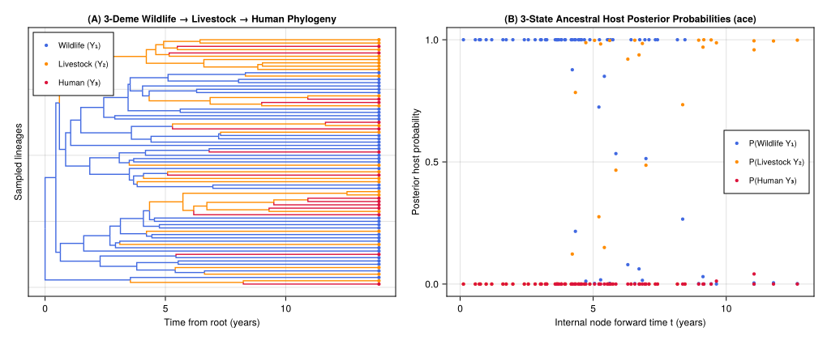

```julia
dm_br = build_demographic_process(bridge_rs, [Y1, Y2, Y3], u0_br, tspan_br, p_br)
sample_states_br = zeros(Float64, ntips(tree_br), 3)
for i in 1:ntips(tree_br)
    sample_states_br[i, clamp(tree_br.tip_state[i], 1, 3)] = 1.0
end
bdt_br = DatedTree(tree_br; sampleStates = sample_states_br, demes = ["Y1", "Y2", "Y3"], minEdgeLength = 1e-4)
bdt_br.maxSampleTime = 14.0
bdt_br_ace = ace(bdt_br, Dict{String,Float64}(), dm_br; res = 300, timeOfOriginBoundaryCondition = false, likelihood = :PL2)

fig_br = Figure(size = (1020, 420), fontsize = 12)
bt, x, y = Phylodynamics._tree_layout_coords(tree_br)
deme_cols = Dict(1 => :royalblue, 2 => :darkorange, 3 => :crimson)

ax_tree = Axis(fig_br[1, 1];
    title = "(A) 3-Deme Wildlife → Livestock → Human Phylogeny",
    xlabel = "Time from root (years)",
    ylabel = "Sampled lineages",
    yticklabelsvisible = false,
    yticksvisible = false
)
for e in 1:size(bt.edge, 1)
    p_n = bt.edge[e, 1]
    c_n = bt.edge[e, 2]
    st_c = clamp(bt.node_state[c_n] > 0 ? bt.node_state[c_n] : 1, 1, 3)
    lines!(ax_tree, [x[p_n], x[p_n], x[c_n]], [y[p_n], y[c_n], y[c_n]]; color = deme_cols[st_c], linewidth = 1.4)
end
for (k, lbl) in [(1, "Wildlife (Y₁)"), (2, "Livestock (Y₂)"), (3, "Human (Y₃)")]
    idx = findall(==(k), bt.tip_state)
    !isempty(idx) && scatter!(ax_tree, x[idx], y[idx]; color = deme_cols[k], markersize = 6, label = lbl)
end
axislegend(ax_tree; position = :lt, framevisible = true, labelsize = 10)

ax_post = Axis(fig_br[1, 2];
    title = "(B) 3-State Ancestral Host Posterior Probabilities (ace)",
    xlabel = "Internal node forward time t (years)",
    ylabel = "Posterior host probability"
)
n_t = bdt_br_ace.n
ints = (n_t + 1):(n_t + bdt_br_ace.Nnode)
t_ints = bdt_br_ace.maxSampleTime .- bdt_br_ace.heights[ints]
scatter!(ax_post, t_ints, bdt_br_ace.acestates[1, ints]; color = :royalblue, markersize = 6, label = "P(Wildlife Y₁)")
scatter!(ax_post, t_ints, bdt_br_ace.acestates[2, ints]; color = :darkorange, markersize = 6, label = "P(Livestock Y₂)")
scatter!(ax_post, t_ints, bdt_br_ace.acestates[3, ints]; color = :crimson, markersize = 6, label = "P(Human Y₃)")
axislegend(ax_post; position = :rc, framevisible = true, labelsize = 10)
fig_br
```